# Task 1: Data preparation and customer analytics

Yixi Deng

7/23/2021

## Load required libraries and datasets

## Exploratory data analysis

### Examining transaction data

We can use `str()` to look at the format of each column and see a sample of data.

```r
#### Examine transaction data
str(transactionData)
```

```
## Classes 'data.table' and 'data.frame':   12043 obs. of  23 variables:
##  $ status           : chr  "authorized" "authorized" "authorized" "authorized" ...
##  $ card_present_flag: int  1 0 1 1 1 NA 1 1 1 NA ...
##  $ bpay_biller_code : chr  "" "" "" "" ...
##  $ account          : chr  "ACC-1598451071" "ACC-1598451071" "ACC-1222300524" "ACC-1037050564" ...
##  $ currency         : chr  "AUD" "AUD" "AUD" "AUD" ...
##  $ long_lat         : chr  "153.41 -27.95" "153.41 -27.95" "151.23 -33.94" "153.10 -27.66" ...
##  $ txn_description  : chr  "POS" "SALES-POS" "POS" "SALES-POS" ...
##  $ merchant_id      : chr  "81c48296-73be-44a7-befa-d053f48ce7cd" "830a451c-316e-4a6a-bf25-e37caedca49e" "835c231d-8cdf-4e96-859d-e9d571760cf0" "48514682-c78a-4a88-b0da-2d6302e64673" ...
##  $ merchant_code    : int  NA NA NA NA NA NA NA NA NA NA ...
##  $ first_name       : chr  "Diana" "Diana" "Michael" "Rhonda" ...
##  $ balance          : num  35.39 21.2 5.71 2117.22 17.95 ...
##  $ date             : chr  "8/1/2018" "8/1/2018" "8/1/2018" "8/1/2018" ...
##  $ gender           : chr  "F" "F" "M" "F" ...
##  $ age              : int  26 26 38 40 26 20 43 43 27 40 ...
##  $ merchant_suburb  : chr  "Ashmore" "Sydney" "Sydney" "Buderim" ...
##  $ merchant_state   : chr  "QLD" "NSW" "NSW" "QLD" ...
##  $ extraction       : POSIXct, format: "2018-08-01 01:01:15" "2018-08-01 01:13:45" ...
##  $ amount           : num  16.25 14.19 6.42 40.9 3.25 ...
##  $ transaction_id   : chr  "a623070bfead4541a6b0fff8a09e706c" "13270a2a902145da9db4c951e04b51b9" "feb79e7ecd7048a5a36ec889d1a94270" "2698170da3704fd981b15e64a006079e" ...
##  $ country          : chr  "Australia" "Australia" "Australia" "Australia" ...
##  $ customer_id      : chr  "CUS-2487424745" "CUS-2487424745" "CUS-2142601169" "CUS-1614226872" ...
##  $ merchant_long_lat: chr  "153.38 -27.99" "151.21 -33.87" "151.21 -33.87" "153.05 -26.68" ...
##  $ movement         : chr  "debit" "debit" "debit" "debit" ...
##  - attr(*, ".internal.selfref")=<externalptr>
```

### Find the missing values

Next, we need to see if there is any null or blank cell in each variable.

```r
# Count both NA and blank cells except extraction
sapply(transactionData[,-"extraction"], function(x) sum(is.na(x)|x == ""))
```

```
##            status card_present_flag  bpay_biller_code           account
##                 0              4326             11158                 0
##          currency          long_lat   txn_description       merchant_id
##                 0                 0                 0              4326
##     merchant_code        first_name           balance              date
##             11160                 0                 0                 0
##            gender               age   merchant_suburb    merchant_state
##                 0                 0              4326              4326
##            amount    transaction_id           country       customer_id
##                 0                 0                 0                 0
## merchant_long_lat          movement
##              4326                 0
```

```r
# Count both NA and blank cells for extraction
sum(sapply(as.numeric(transactionData$extraction), function(x) sum(is.na(x)|x == "")))
```

```
## [1] 0
```

There are 4326 missing values in `card_present_flag` column, 11158 missing values in `bpay_biller_code` column, 4326 missing values in `merchant_id` column, 11160 missing values in `merchant_code` column, 4326 missing values in `merchant_suburb` column, 4326 missing values in `merchant_state` column, and 4326 missing values in `merchant_long_lat` column.

### Change the formats for some variables

```r
#### Convert status column to a factor format
transactionData$status <- as.factor(transactionData$status)
#### Convert date column to a date format
transactionData$date <- as.Date(transactionData$date, format = "%m/%d/%Y")
#### Convert gender column to a factor format
transactionData$gender <- as.factor(transactionData$gender)
#### Convert merchant_state column to a factor format
transactionData$merchant_state <- as.factor(transactionData$merchant_state)
#### Convert movement column to a factor format
transactionData$movement <- as.factor(transactionData$movement)
str(transactionData)
```

```
## Classes 'data.table' and 'data.frame':   12043 obs. of  23 variables:
##  $ status           : Factor w/ 2 levels "authorized","posted": 1 1 1 1 1 2 1 1 1 2 ...
##  $ card_present_flag: int  1 0 1 1 1 NA 1 1 1 NA ...
##  $ bpay_biller_code : chr  "" "" "" "" ...
##  $ account          : chr  "ACC-1598451071" "ACC-1598451071" "ACC-1222300524" "ACC-1037050564" ...
##  $ currency         : chr  "AUD" "AUD" "AUD" "AUD" ...
##  $ long_lat         : chr  "153.41 -27.95" "153.41 -27.95" "151.23 -33.94" "153.10 -27.66" ...
##  $ txn_description  : chr  "POS" "SALES-POS" "POS" "SALES-POS" ...
##  $ merchant_id      : chr  "81c48296-73be-44a7-befa-d053f48ce7cd" "830a451c-316e-4a6a-bf25-e37caedca49e" "835c231d-8cdf-4e96-859d-e9d571760cf0" "48514682-c78a-4a88-b0da-2d6302e64673" ...
##  $ merchant_code    : int  NA NA NA NA NA NA NA NA NA NA ...
##  $ first_name       : chr  "Diana" "Diana" "Michael" "Rhonda" ...
##  $ balance          : num  35.39 21.2 5.71 2117.22 17.95 ...
##  $ date             : Date, format: "2018-08-01" "2018-08-01" ...
##  $ gender           : Factor w/ 2 levels "F","M": 1 1 2 1 1 2 1 1 1 2 ...
##  $ age              : int  26 26 38 40 26 20 43 43 27 40 ...
##  $ merchant_suburb  : chr  "Ashmore" "Sydney" "Sydney" "Buderim" ...
##  $ merchant_state   : Factor w/ 9 levels "","ACT","NSW",..: 5 3 3 5 5 1 8 8 9 1 ...
##  $ extraction       : POSIXct, format: "2018-08-01 01:01:15" "2018-08-01 01:13:45" ...
##  $ amount           : num  16.25 14.19 6.42 40.9 3.25 ...
##  $ transaction_id   : chr  "a623070bfead4541a6b0fff8a09e706c" "13270a2a902145da9db4c951e04b51b9" "feb79e7ecd7048a5a36ec889d1a94270" "2698170da3704fd981b15e64a006079e" ...
##  $ country          : chr  "Australia" "Australia" "Australia" "Australia" ...
##  $ customer_id      : chr  "CUS-2487424745" "CUS-2487424745" "CUS-2142601169" "CUS-1614226872" ...
##  $ merchant_long_lat: chr  "153.38 -27.99" "151.21 -33.87" "151.21 -33.87" "153.05 -26.68" ...
##  $ movement         : Factor w/ 2 levels "credit","debit": 2 2 2 2 2 2 2 2 2 2 ...
##  - attr(*, ".internal.selfref")=<externalptr>
```

```r
# Show them in percentage for non-character variables
sapply(transactionData[,c("merchant_code","balance","gender","age","merchant_state","amount","movement","long_lat")],
function(x) sum(is.na(x)|x == "")/length(x)*100)
```

```
##  merchant_code        balance         gender            age merchant_state
##       92.66794        0.00000        0.00000        0.00000       35.92128
##         amount       movement       long_lat
##        0.00000        0.00000        0.00000
```

We found 92.67% of data in `merchant_code` column and 35.92% of data in `merchant_state` column. We’ll leave the missing values in `merchant_code` and `merchant_state` right now, and if necessary, we’ll try to fill those missing values for future analysis.

### Find the missing date

```r
#### Find the missing date
DateRange <- seq(range(transactionData$date)[1],range(transactionData$date)[2],by=1)
DateRange[!DateRange %in% transactionData$date]
```

```
## [1] "2018-08-16"
```

We found one date was not in the dataset. We would go back to this, if this date is important for the analysis.

### Create new variable

```r
#### Create month variable
transactionData$month <-
  ifelse(month(transactionData$date) == 8, "Aug",
         ifelse(month(transactionData$date) == 9, "Sep", "Oct"))
table(transactionData$month)
```

```
##
##  Aug  Oct  Sep
## 3943 4087 4013
```

```r
sum(table(transactionData$month))
```

```
## [1] 12043
```

We created new variable `month` for comparing the transactions on those three months.

### Find the outliers

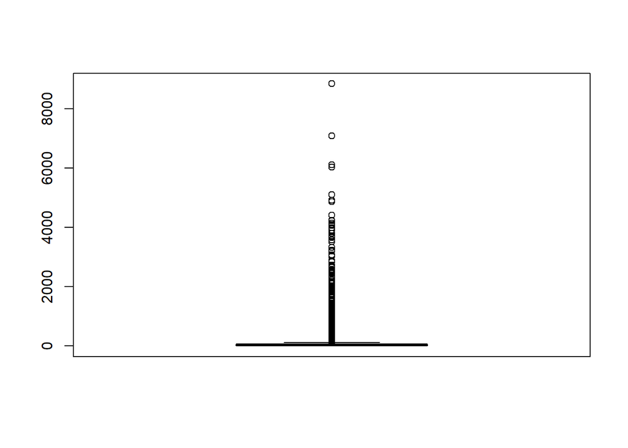

```r
#### Find the outliers in amount column
boxplot(transactionData$amount)
```

```r
#### Check the stats of the normal amount data
boxplot.stats(transactionData$amount)$stats
```

```
## [1]   0.100  16.000  29.000  53.655 110.000
```

```r
#### Check the proportion of the outliers
sum(transactionData$amount > 110)/length(transactionData$amount)
```

```
## [1] 0.153118
```

```r
#### Check whether the outlier amounts belong to specific customers
table(transactionData$customer_id[transactionData$amount > 110])
```

```
##
## CUS-1005756958 CUS-1117979751 CUS-1140341822 CUS-1147642491 CUS-1196156254
##             29             16             12             31             19
## CUS-1220154422 CUS-1233833708 CUS-1271030853  CUS-127297539  CUS-134193016
##             25             21             24             21             11
##  CUS-134833760 CUS-1388323263 CUS-1433879684 CUS-1462656821 CUS-1478398256
##             18             22             11             24             20
## CUS-1499065773 CUS-1604596597 CUS-1609060617 CUS-1614226872 CUS-1617121891
##             16              8             21             20             23
##  CUS-164374203 CUS-1646183815 CUS-1646621553 CUS-1654129794 CUS-1669695324
##             26             18             21             19             24
## CUS-1739931018 CUS-1790886359 CUS-1816693151 CUS-1842679196 CUS-1892177589
##              5             18             16             18             20
## CUS-1896554896 CUS-1928710999 CUS-2031327464 CUS-2059096722 CUS-2083971310
##             12             14             27             20             13
## CUS-2110742437 CUS-2142601169 CUS-2155701614 CUS-2178051368 CUS-2206365095
##              5             19             25              7              8
## CUS-2283904812 CUS-2317998716 CUS-2348881191 CUS-2370108457 CUS-2376382098
##              8              7             10             16             17
## CUS-2484453271 CUS-2487424745 CUS-2500783281 CUS-2505971401 CUS-2599279756
##             10             22             27             22             16
##  CUS-261674136 CUS-2630892467 CUS-2650223890 CUS-2663907001 CUS-2688605418
##             14             14             24             22             23
## CUS-2695611575 CUS-2738291516 CUS-2819545904 CUS-2977593493 CUS-3026014945
##             23             22             26             15             21
## CUS-3117610635 CUS-3129499595 CUS-3142625864 CUS-3151318058 CUS-3174332735
##             23             30             27             14             16
## CUS-3180318393 CUS-3201519139 CUS-3249305314  CUS-325142416 CUS-3255104878
##             18             23             28             18             18
##  CUS-326006476  CUS-331942311 CUS-3325710106 CUS-3336454548 CUS-3378712515
##             18             11             21             13             21
## CUS-3395687666 CUS-3431016847 CUS-3462882033 CUS-3702001629 CUS-3716701010
##             15             13             13             17             25
## CUS-3904958894 CUS-3989008654 CUS-4023861240 CUS-4123612273 CUS-4142663097
##             20             12             19             32             32
##  CUS-423725039  CUS-443776336  CUS-495599312  CUS-497688347  CUS-511326734
##              8             16             21             18             18
##   CUS-51506836  CUS-527400765  CUS-537508723   CUS-55310383  CUS-586638664
##             12             24             17             25             15
##   CUS-72755508  CUS-809013380  CUS-860700529  CUS-880898248  CUS-883482547
##             16             21             19             10             21
```

```r
uniqueN(transactionData$customer_id[transactionData$amount > 110])
```

```
## [1] 100
```

```r
uniqueN(transactionData$customer_id)
```

```
## [1] 100
```

From the plot above, we can see that there are over 15% of transactions which exceeded 110 dollars. However, we can’t remove those transaction data as outliers, for every customer has multiple transactions over 110 dollars.

## Insights Exploration

### Average transaction amount

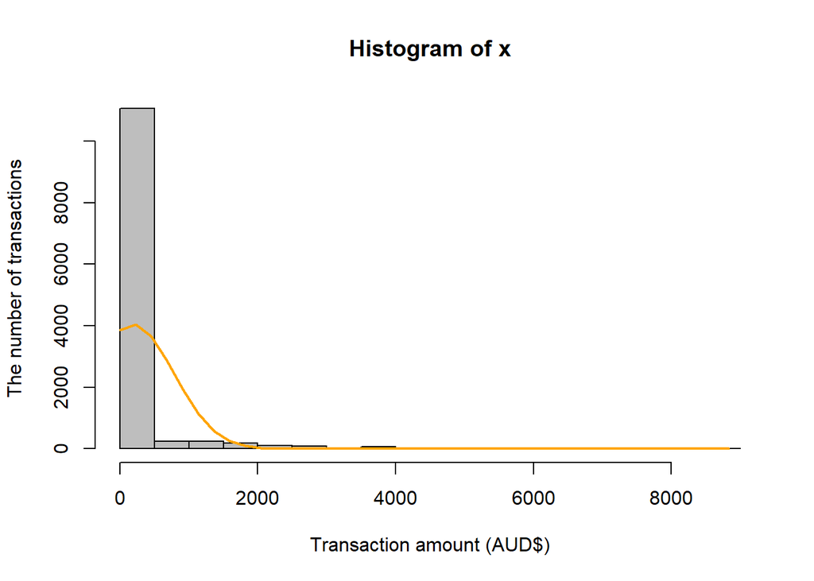

```r
# Histogram
x <- transactionData$amount
h <- hist(x,breaks = 20, col = "grey",
          xlab = "Transaction amount (AUD$)",
          ylab = "The number of transactions")
xfit <- seq(min(x),max(x),length=40)
yfit <- dnorm(xfit, mean = mean(x), sd=sd(x))
yfit <- yfit*diff(h$mids[1:2])*length(x)
lines(xfit,yfit,col="orange",lwd=2)
```

```r
# Main statistics
mean(x)
```

```
## [1] 187.9336
```

```r
median(x)
```

```
## [1] 29
```

```r
max(x)
```

```
## [1] 8835.98
```

The distribution of `amount` has a positive skew. Half of `amount` are less than 29 dollars; however, the mean of `amount` is 187.9336 dollars, which indicates the other half of `amount` is much larger than the half which are less than 29 dollars.

### The average number of transactions per customer each month

```r
### The average number of transaction per customer on Aug 2018
total_txn_n_Aug <- uniqueN(transactionData$transaction_id[transactionData$month == "Aug"])
total_cust_n_Aug <- uniqueN(transactionData$customer_id[transactionData$month == "Aug"])
(avg_txn_n_per_customer_Aug <- total_txn_n_Aug/total_cust_n_Aug)
```

```
## [1] 39.43
```

```r
### The average number of transaction per customer on Sep 2018
total_txn_n_Sep <- uniqueN(transactionData$transaction_id[transactionData$month == "Sep"])
total_cust_n_Sep <- uniqueN(transactionData$customer_id[transactionData$month == "Sep"])
(avg_txn_n_per_customer_Sep <- total_txn_n_Sep/total_cust_n_Sep)
```

```
## [1] 40.13
```

```r
### The average number of transaction per customer on Oct 2018
total_txn_n_Oct <- uniqueN(transactionData$transaction_id[transactionData$month == "Oct"])
total_cust_n_Oct <- uniqueN(transactionData$customer_id[transactionData$month == "Oct"])
(avg_txn_n_per_customer_Oct <- total_txn_n_Oct/total_cust_n_Oct)
```

```
## [1] 40.87
```

On average, every customer had about 40 transactions in each month. Now, let’s see whether we can find any interesting behaviours for different lengths of time.

### Segment the dataset by transaction date and time

```r
#### Split the time out of the extraction column into the time column
transactionData$time <- substr(transactionData$extraction,12,19)
```

```r
#### Split the date into two columns, weekday, and weekend
transactionData$day <- weekdays(transactionData$date)
```

### Visualise transaction spending over the course of an average day or week

```r
total_txn_n <- uniqueN(transactionData$transaction_id)
total_day_n <- uniqueN(transactionData$date)
avg_txn_n_per_day <- total_txn_n/total_day_n
txn_n_df <- transactionData %>% group_by(date) %>% summarise_at(vars(transaction_id),list(n = uniqueN))
txn_n_df$day <- weekdays(txn_n_df$date)
head(txn_n_df)
```

| date | n | day |
| --- | --- | --- |
| 2018-08-01 | 137 | Wednesday |
| 2018-08-02 | 152 | Thursday |
| 2018-08-03 | 157 | Friday |
| 2018-08-04 | 118 | Saturday |
| 2018-08-05 | 100 | Sunday |
| 2018-08-06 | 99 | Monday |

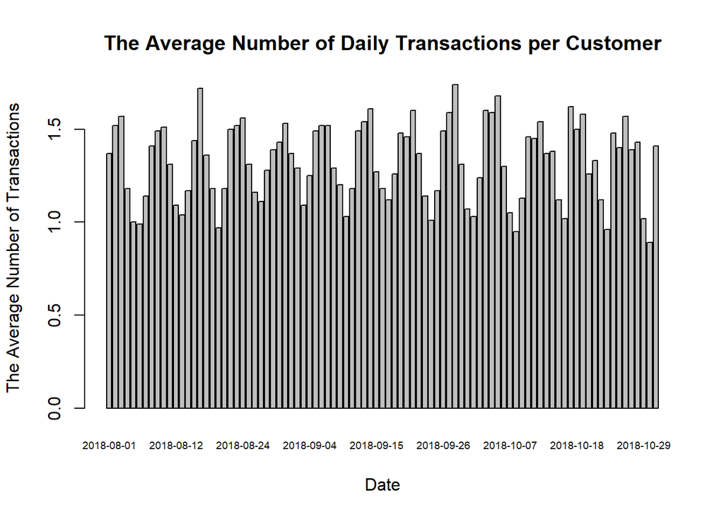

```r
#### Plot the transaction volume over the course of an average day
barplot(txn_n_df$n/100, names.arg = txn_n_df$date,
        cex.names = 0.6,
        xlab = "Date",
        ylab = "The Average Number of Transactions",
        main = "The Average Number of Daily Transactions per Customer")
```

We can see a clear pattern in the plot above. Peaks and troughs frequently appeared in the plot. Let’s take a closer look.

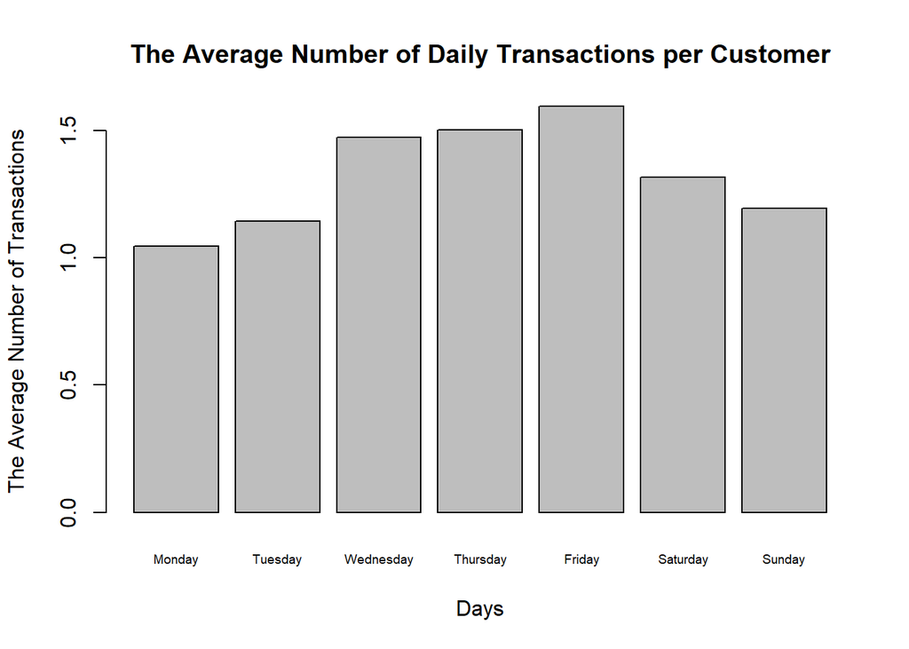

```r
txn_n_df1 <- txn_n_df %>% group_by(day) %>% summarise(n = mean(n))
txn_n_df1.0 <- txn_n_df1[c(2,6,7,5,1,3,4),]


#### Plot the transaction volume over days
barplot(txn_n_df1.0$n/100, names.arg = txn_n_df1.0$day,
        cex.names = 0.6,
        xlab = "Days",
        ylab = "The Average Number of Transactions",
        main = "The Average Number of Daily Transactions per Customer")
```

It seems like customers tend to have more transactions between Wednesday and Friday. How about the number of transactions within a day?

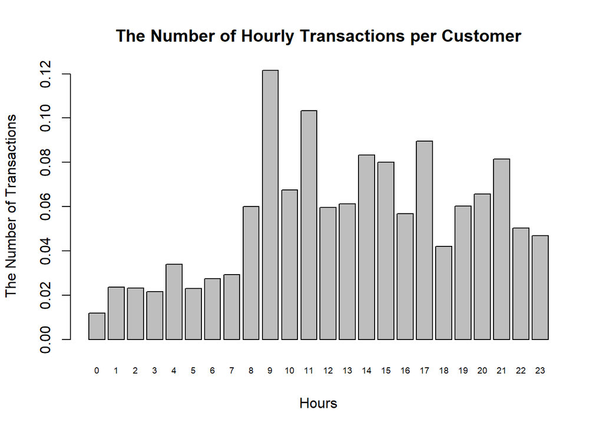

```r
transactionData$hour <- as.integer(substr(transactionData$time,1,2))
txn_n_df2 <- transactionData %>% group_by(hour) %>% summarise_at(vars(transaction_id),list(n = uniqueN))

#### Plot the transaction volume over the course of an average day
barplot(txn_n_df2$n/(100*uniqueN(transactionData$date)), names.arg = txn_n_df2$hour,
        cex.names = 0.6,
        xlab = "Hours",
        ylab = "The Number of Transactions",
        main = "The Number of Hourly Transactions per Customer")
```

From the plot above, we can see that most of custmoers purchase something around 9:00 am, 11:00 am, and 5:00 pm. Not surprisely, those times are meal times.

After exploring some insights of the number of transactions, let’s have a look at the transaction spending for different lengths of time.

### Visualise transaction spending over the course of an average day or week

```r
spending_df <- transactionData %>% group_by(date) %>%  summarise_at(vars(amount),list(spending = sum))
avg_spending_df <- merge(spending_df,txn_n_df)
avg_spending_df$avg_spending <- avg_spending_df$spending/avg_spending_df$n
head(avg_spending_df)
```

|  | date | spending | n | day | avg_spending |
| --- | --- | --- | --- | --- | --- |
| 1 | 2018-08-01 | 29867.94 | 137 | Wednesday | 218.01416 |
| 2 | 2018-08-02 | 21786.32 | 152 | Thursday | 143.33105 |
| 3 | 2018-08-03 | 38096.58 | 157 | Friday | 242.65338 |
| 4 | 2018-08-04 | 6296.05 | 118 | Saturday | 53.35636 |
| 5 | 2018-08-05 | 4426.50 | 100 | Sunday | 44.26500 |
| 6 | 2018-08-06 | 42288.23 | 99 | Monday | 427.15384 |

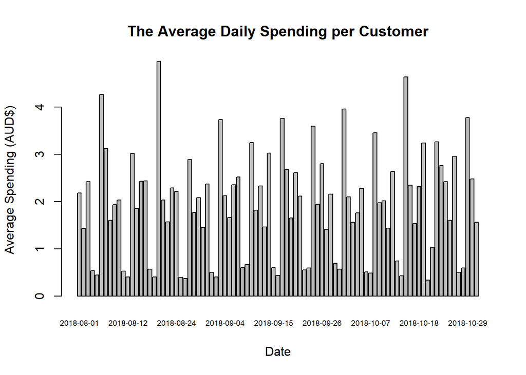

```r
#### Plot the transaction volume over the course of an average day
barplot(avg_spending_df$avg_spending/100, names.arg = avg_spending_df$date,
        cex.names = 0.6,
        xlab = "Date",
        ylab = "Average Spending (AUD$)",
        main = "The Average Daily Spending per Customer")
```

The pattern of average daily spending per customer is similar to that in the average number of daily transactions per customer. Peaks and troughs occurred periodically. Now, let’s have a closer look.

```r
spending_df1 <- transactionData %>% group_by(day) %>%  summarise_at(vars(amount),list(spending = sum))
avg_spending_df1 <- merge(spending_df1,txn_n_df2)
avg_spending_df1$avg_spending <- avg_spending_df1$spending/avg_spending_df1$n
avg_spending_df1$avg_spending_per_customer <- avg_spending_df1$avg_spending/100
head(avg_spending_df1)
```

|  | day | spending | hour | n | avg_spending | avg_spending_per_customer |
| --- | --- | --- | --- | --- | --- | --- |
| 1 | Friday | 516909.84 | 0 | 108 | 4786.2022 | 47.862022 |
| 2 | Monday | 507580.56 | 0 | 108 | 4699.8200 | 46.998200 |
| 3 | Saturday | 93002.56 | 0 | 108 | 861.1348 | 8.611348 |
| 4 | Sunday | 82174.56 | 0 | 108 | 760.8756 | 7.608756 |
| 5 | Thursday | 331402.77 | 0 | 108 | 3068.5442 | 30.685442 |
| 6 | Tuesday | 329484.19 | 0 | 108 | 3050.7795 | 30.507795 |

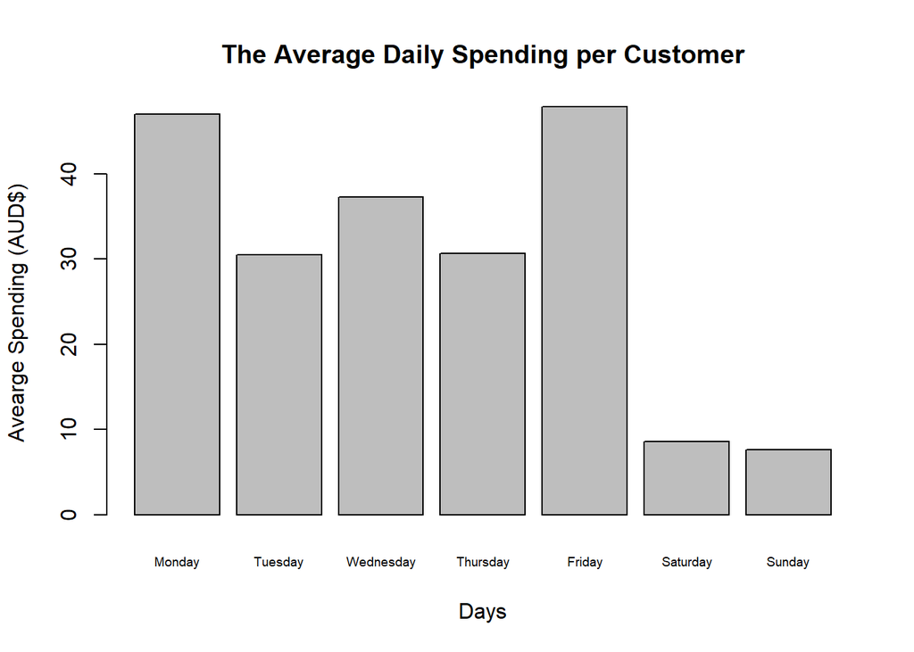

```r
avg_spending_df1.0 <- avg_spending_df1[c(2,6,7,5,1,3,4),]

#### Plot the transaction volume over weekdays
barplot(avg_spending_df1.0$avg_spending_per_customer, names.arg = avg_spending_df1.0$day,
        cex.names = 0.6,
        xlab = "Days",
        ylab = "Avearge Spending (AUD$)",
        main = "The Average Daily Spending per Customer")
```

It seems like customers tend to spend more on Monday and Friday and spend least on weekend. Next, we take a look at the hourly transaction spending.

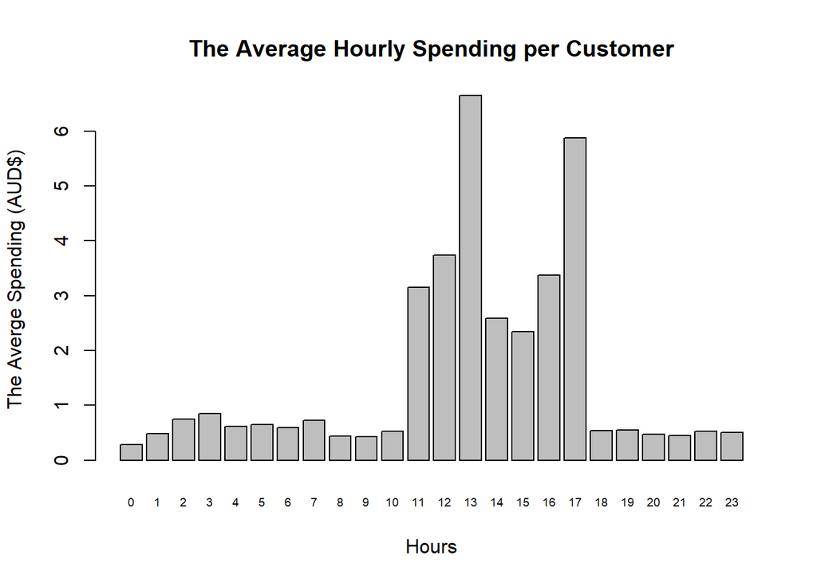

```r
avg_spending_df2 <- transactionData %>% group_by(hour) %>% summarise_at(vars(amount),list(avg_spending = mean))
avg_spending_df2$avg_spending_per_customer <- avg_spending_df2$avg_spending/100


#### Plot the transaction volume over the course of an average day
barplot(avg_spending_df2$avg_spending_per_customer, names.arg = avg_spending_df2$hour,
        cex.names = 0.6,
        xlab = "Hours",
        ylab = "The Averge Spending (AUD$)",
        main = "The Average Hourly Spending per Customer")
```

Customers tend to spend the most at 1:00 pm and 5:00 pm.

### Location information

Let’s have a look where the customers are from based on the information in `long_lat` column.

#### Create a new dataframe with information with only account number and coordinates

```r
account_loc_inf <- transactionData[match(unique(transactionData$account),transactionData$account), c("account","long_lat")]
account_loc_inf$long <- as.numeric(substr(account_loc_inf$long_lat,1,6))
account_loc_inf$lat <- as.numeric(substr(account_loc_inf$long_lat,8,13))
head(account_loc_inf)
```

| account | long_lat | long | lat |
| --- | --- | --- | --- |
| ACC-1598451071 | 153.41 -27.95 | 153.41 | -27.95 |
| ACC-1222300524 | 151.23 -33.94 | 151.23 | -33.94 |
| ACC-1037050564 | 153.10 -27.66 | 153.10 | -27.66 |
| ACC-1608363396 | 151.22 -33.87 | 151.22 | -33.87 |
| ACC-2776252858 | 144.95 -37.76 | 144.95 | -37.76 |
| ACC-182446574 | 116.06 -32.00 | 116.06 | -32.00 |

#### Create a function to find the state given the coordinates

```r
coords_state <- function(coords_state, loc_inf,state_name){
        loc_inf$states <- ifelse(loc_inf$long <= coords_state[[1]][3] &
                                 loc_inf$long >= coords_state[[1]][1] &
                                 loc_inf$lat <=  coords_state[[1]][4] &
                                 loc_inf$lat >= coords_state[[1]][2],
                                 state_name,loc_inf$states)
}
```

#### Define the coordinates for each state

```r
coords_NSW <- as.data.frame(c(140.9993, -37.50503, 153.6299, -28.15703 ),c("xmin","ymin","xmax","ymax"))
coords_VIC <- as.data.frame(c(140.9617, -39.13396, 149.9763, -33.99605 ),c("xmin","ymin","xmax","ymax"))
coords_QLD <- as.data.frame(c(137.9943, -29.17719, 153.5522, -9.229287 ),c("xmin","ymin","xmax","ymax"))
coords_SA <- as.data.frame(c(129.0013, -38.06, 141.003, -25.99638 ),c("xmin","ymin","xmax","ymax"))
coords_WA <- as.data.frame(c(112.9211, -35.12228, 129.0019, -13.74142 ),c("xmin","ymin","xmax","ymax"))
coords_TAS <- as.data.frame(c(143.8353, -43.63203, 148.4472, -39.45196 ),c("xmin","ymin","xmax","ymax"))
coords_NT <- as.data.frame(c(129.0005, -25.99862, 137.9991, -10.97392 ),c("xmin","ymin","xmax","ymax"))
coords_ACT <- as.data.frame(c(148.7628, -148.7628, 149.3972, -35.12442 ),c("xmin","ymin","xmax","ymax"))
```

#### Update the location information dataframe with states

```r
account_loc_inf$states <- NA

account_loc_inf$states <- coords_state(coords_NSW, account_loc_inf, "NSW")
account_loc_inf$states <- coords_state(coords_VIC, account_loc_inf, "VIC")
account_loc_inf$states <- coords_state(coords_QLD, account_loc_inf, "QLD")
account_loc_inf$states <- coords_state(coords_SA, account_loc_inf, "SA")
account_loc_inf$states <- coords_state(coords_WA, account_loc_inf, "WA")
account_loc_inf$states <- coords_state(coords_TAS, account_loc_inf, "TAS")
account_loc_inf$states <- coords_state(coords_NT, account_loc_inf, "NT")
account_loc_inf$states <- coords_state(coords_ACT, account_loc_inf, "ACT")

head(account_loc_inf)
```

| account | long_lat | long | lat | states |
| --- | --- | --- | --- | --- |
| ACC-1598451071 | 153.41 -27.95 | 153.41 | -27.95 | QLD |
| ACC-1222300524 | 151.23 -33.94 | 151.23 | -33.94 | NSW |
| ACC-1037050564 | 153.10 -27.66 | 153.10 | -27.66 | QLD |
| ACC-1608363396 | 151.22 -33.87 | 151.22 | -33.87 | NSW |
| ACC-2776252858 | 144.95 -37.76 | 144.95 | -37.76 | VIC |
| ACC-182446574 | 116.06 -32.00 | 116.06 | -32.00 | WA |

#### Make a bar plot to display the location distribution of customers

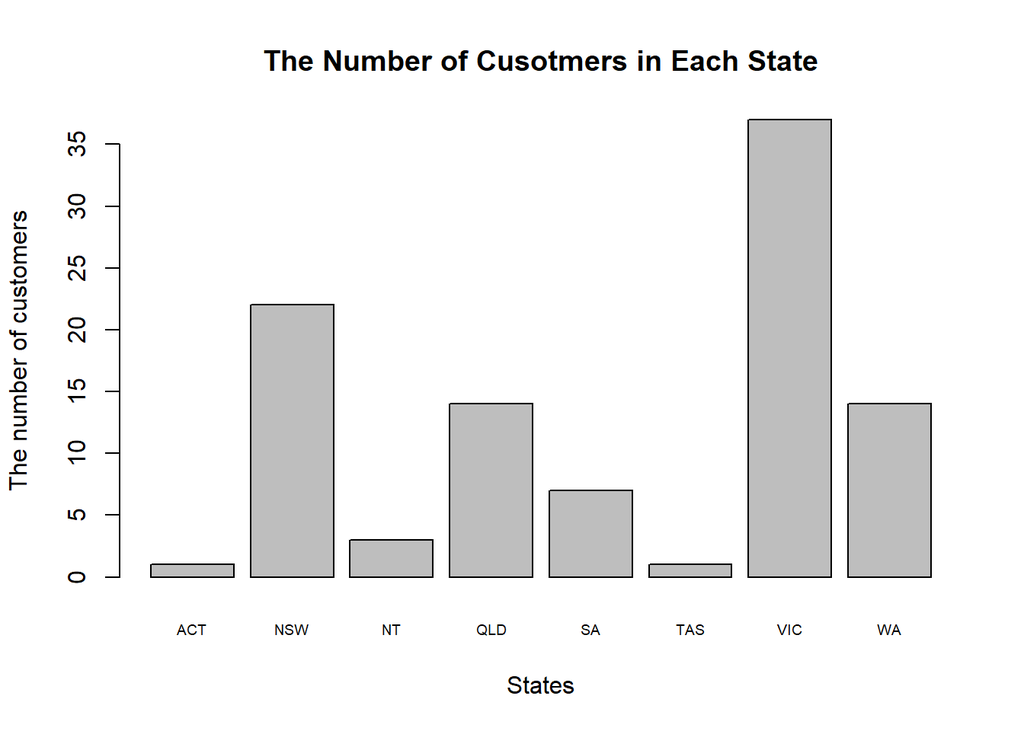

```r
#### Create a dataframe with the number of cusomters in each state
state_freq_df <- as.data.frame(table(account_loc_inf$states))

#### Make a bar plot
barplot(state_freq_df$Freq, names.arg = state_freq_df$Var1,
        cex.names = 0.6,
        xlab = "States", ylab = "The number of customers",
        main = "The Number of Cusotmers in Each State"
        )
```

As the plot shown above, most of customers are from Victoria and New South Wales states.